# STUBBS_Skills_Test_3

Josh Stubbs

2023-11-22

# Goal of test

The goal is to us Rstudio to clean and analyze the 2 provided datasets. This will include cleaning data, modeling, and data analysis.

# Task 1: “FacultySalaries_1995.csv”

The first task involves loading and cleaning the “FacultySalaries_1995.csv” dataset. It is important to understand what is in the data set to better analyze and clean it.

# Read Data:

```r
FacultySalaries_1995 <- read_csv("FacultySalaries_1995.csv")
fsalary <- FacultySalaries_1995
```

# Clean Data:

Pivot_longer column is used to stretch longer and split columns.

```r
fsalary <- fsalary %>%
  pivot_longer(cols = c("AvgFullProfSalary", "AvgAssocProfSalary", "AvgAssistProfSalary"),
               names_to = "Rank",
               values_to = "Salary") %>%
  pivot_longer(cols = c("AvgFullProfComp", "AvgAssocProfComp", "AvgAssistProfComp"),
               names_to = "Rank_Comp",
               values_to = "Compensation") %>%
  pivot_longer(cols = c("NumFullProfs", "NumAssocProfs", "NumAssistProfs", "NumInstructors"),
               names_to = "Rank_Num",
               values_to = "Staff_Number") %>%
  mutate(Rank = case_when(Rank == "AvgFullProfSalary" ~ "Full",
                          Rank == "AvgAssocProfSalary" ~ "Assoc",
                          Rank == "AvgAssistProfSalary" ~ "Assist"))
```

# Filter Data:

clears rows where the “Tier” variable is equal to “VIIB”.

```r
fsalary <- fsalary[!(fsalary$Tier=="VIIB"), ]
```

# Visual Data:

create a boxplot of salary distribution (Salary) across different faculty ranks (Rank), with each rank having a different fill color.

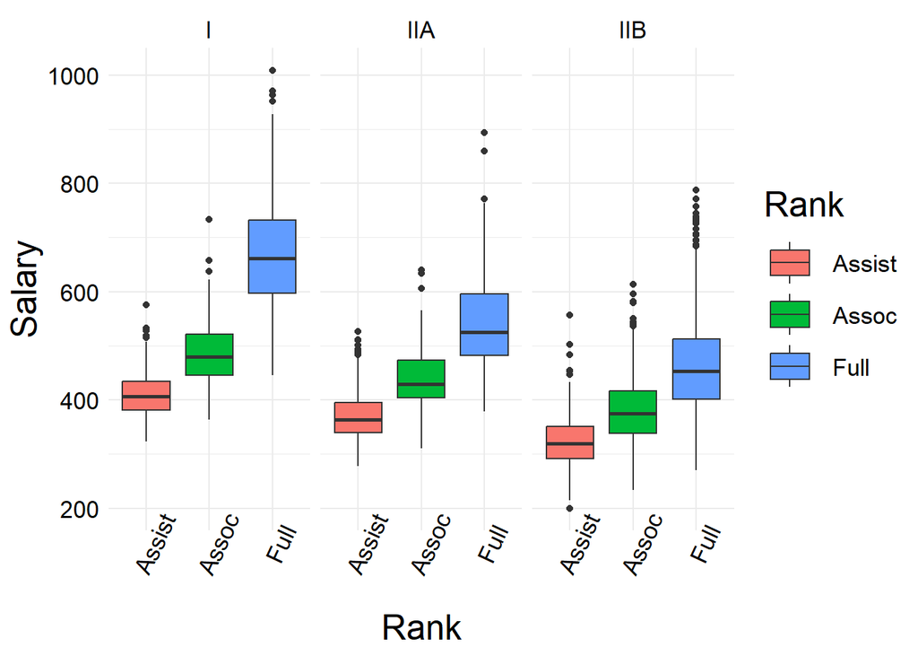

```r
fsalary %>%
  ggplot(aes(x=Rank,y=Salary)) +
  geom_boxplot(aes(fill=Rank)) +
  facet_wrap(~Tier) +
  theme_minimal() +
  theme(legend.key.size = unit(1, "cm"),
        legend.title = element_text(size = 19, color = "black"),
        legend.text = element_text(size = 13, color = "black"),
        axis.text.x = element_text(angle = 65, size = 13, color = "black"),
        axis.text.y = element_text(size = 13, color = "black"),
        axis.title.x = element_text(size = 19, color = "black"),
        axis.title.y = element_text(size = 19, color = "black"),
        strip.text.x = element_text(size = 13, color = "black"))
```

# Export Figure:

The ggsave function is then used to save the created plot as a JPEG image.

```r
ggsave("./STUBBS_fig_1.jpg")
```

# Task 2: ANOVA Modeling

In the second task an (ANOVA) model is made to examine the influence of “State,” “Tier,” and “Rank” on “Salary.”

# Build and Analyze ANOVA Model:

This code creates a generalized linear model (GLM) where Salary is shown as a function of Rank, State, and Tier in the data set. The summary function of the fitted GLM model, shows coefficients, standard errors, t-values, and p-values.

```r
model_1 <- glm(data = fsalary,
            formula = Salary ~ Rank + State + Tier )
summary(model_1)
```

```
##
## Call:
## glm(formula = Salary ~ Rank + State + Tier, data = fsalary)
##
## Coefficients:
##              Estimate Std. Error  t value Pr(>|t|)
## (Intercept)  474.8303     5.0459   94.103  < 2e-16 ***
## RankAssoc     63.8648     0.7269   87.861  < 2e-16 ***
## RankFull     170.7936     0.7323  233.227  < 2e-16 ***
## StateAL      -70.5033     5.4425  -12.954  < 2e-16 ***
## StateAR      -55.2513     5.6189   -9.833  < 2e-16 ***
## StateAZ      -84.7490     7.0680  -11.991  < 2e-16 ***
## StateCA       22.5666     5.1729    4.362 1.29e-05 ***
## StateCO      -40.9601     5.6281   -7.278 3.46e-13 ***
## StateCT       37.7434     5.5903    6.752 1.48e-11 ***
## StateDC       -9.2455     6.0359   -1.532 0.125591
## StateDE      -17.9477     7.2128   -2.488 0.012840 *
## StateFL      -39.7518     5.4869   -7.245 4.41e-13 ***
## StateGA      -38.4238     5.4423   -7.060 1.69e-12 ***
## StateHI       35.4495     7.8922    4.492 7.08e-06 ***
## StateIA      -36.2554     5.3840   -6.734 1.67e-11 ***
## StateID      -87.7027     6.6913  -13.107  < 2e-16 ***
## StateIL      -31.3172     5.1984   -6.024 1.71e-09 ***
## StateIN      -44.3132     5.2428   -8.452  < 2e-16 ***
## StateKS     -103.2112     5.5272  -18.673  < 2e-16 ***
## StateKY      -68.8638     5.4396  -12.660  < 2e-16 ***
## StateLA      -65.7397     5.4712  -12.015  < 2e-16 ***
## StateMA       33.9068     5.2220    6.493 8.51e-11 ***
## StateMD       -9.5552     5.4358   -1.758 0.078787 .
## StateME      -24.4723     5.6956   -4.297 1.74e-05 ***
## StateMI      -21.4590     5.3127   -4.039 5.37e-05 ***
## StateMN      -18.8538     5.3772   -3.506 0.000455 ***
## StateMO      -61.5677     5.2955  -11.626  < 2e-16 ***
## StateMS     -101.5776     5.7425  -17.689  < 2e-16 ***
## StateMT     -119.9167     6.1077  -19.634  < 2e-16 ***
## StateNC      -46.8206     5.2364   -8.941  < 2e-16 ***
## StateND      -84.8973     6.5149  -13.031  < 2e-16 ***
## StateNE      -56.4069     5.5809  -10.107  < 2e-16 ***
## StateNH      -43.7391     5.8288   -7.504 6.32e-14 ***
## StateNJ       63.8223     5.3997   11.820  < 2e-16 ***
```

[output cut: 17 more lines]

```
## StateWV      -79.6295     5.6261  -14.154  < 2e-16 ***
## StateWY     -112.0497    11.1696  -10.032  < 2e-16 ***
## TierIIA      -79.3313     0.9336  -84.974  < 2e-16 ***
## TierIIB     -131.8697     0.8872 -148.630  < 2e-16 ***
## ---
## Signif. codes:  0 '***' 0.001 '**' 0.01 '*' 0.05 '.' 0.1 ' ' 1
##
## (Dispersion parameter for gaussian family taken to be 3581.195)
##
##     Null deviance: 495046352  on 40223  degrees of freedom
## Residual deviance: 143853024  on 40169  degrees of freedom
##   (1536 observations deleted due to missingness)
## AIC: 443379
##
## Number of Fisher Scoring iterations: 2
```

# Export ANOVA Summary:

The sink function saves the output to a file (“Salary_ANOVA_Summary.txt”) instead of the console, providing a written summary of the ANOVA results.

```r
anova(model_1)
```

```
## Analysis of Deviance Table
##
## Model: gaussian, link: identity
##
## Response: Salary
##
## Terms added sequentially (first to last)
##
##
##       Df  Deviance Resid. Df Resid. Dev
## NULL                   40223  495046352
## Rank   2 201878480     40221  293167871
## State 50  67451018     40171  225716853
## Tier   2  81863829     40169  143853024
```

```r
summary(model_1)
```

```
##
## Call:
## glm(formula = Salary ~ Rank + State + Tier, data = fsalary)
##
## Coefficients:
##              Estimate Std. Error  t value Pr(>|t|)
## (Intercept)  474.8303     5.0459   94.103  < 2e-16 ***
## RankAssoc     63.8648     0.7269   87.861  < 2e-16 ***
## RankFull     170.7936     0.7323  233.227  < 2e-16 ***
## StateAL      -70.5033     5.4425  -12.954  < 2e-16 ***
## StateAR      -55.2513     5.6189   -9.833  < 2e-16 ***
## StateAZ      -84.7490     7.0680  -11.991  < 2e-16 ***
## StateCA       22.5666     5.1729    4.362 1.29e-05 ***
## StateCO      -40.9601     5.6281   -7.278 3.46e-13 ***
## StateCT       37.7434     5.5903    6.752 1.48e-11 ***
## StateDC       -9.2455     6.0359   -1.532 0.125591
## StateDE      -17.9477     7.2128   -2.488 0.012840 *
## StateFL      -39.7518     5.4869   -7.245 4.41e-13 ***
## StateGA      -38.4238     5.4423   -7.060 1.69e-12 ***
## StateHI       35.4495     7.8922    4.492 7.08e-06 ***
## StateIA      -36.2554     5.3840   -6.734 1.67e-11 ***
## StateID      -87.7027     6.6913  -13.107  < 2e-16 ***
## StateIL      -31.3172     5.1984   -6.024 1.71e-09 ***
## StateIN      -44.3132     5.2428   -8.452  < 2e-16 ***
## StateKS     -103.2112     5.5272  -18.673  < 2e-16 ***
## StateKY      -68.8638     5.4396  -12.660  < 2e-16 ***
## StateLA      -65.7397     5.4712  -12.015  < 2e-16 ***
## StateMA       33.9068     5.2220    6.493 8.51e-11 ***
## StateMD       -9.5552     5.4358   -1.758 0.078787 .
## StateME      -24.4723     5.6956   -4.297 1.74e-05 ***
## StateMI      -21.4590     5.3127   -4.039 5.37e-05 ***
## StateMN      -18.8538     5.3772   -3.506 0.000455 ***
## StateMO      -61.5677     5.2955  -11.626  < 2e-16 ***
## StateMS     -101.5776     5.7425  -17.689  < 2e-16 ***
## StateMT     -119.9167     6.1077  -19.634  < 2e-16 ***
## StateNC      -46.8206     5.2364   -8.941  < 2e-16 ***
## StateND      -84.8973     6.5149  -13.031  < 2e-16 ***
## StateNE      -56.4069     5.5809  -10.107  < 2e-16 ***
## StateNH      -43.7391     5.8288   -7.504 6.32e-14 ***
## StateNJ       63.8223     5.3997   11.820  < 2e-16 ***
```

[output cut: 17 more lines]

```
## StateWV      -79.6295     5.6261  -14.154  < 2e-16 ***
## StateWY     -112.0497    11.1696  -10.032  < 2e-16 ***
## TierIIA      -79.3313     0.9336  -84.974  < 2e-16 ***
## TierIIB     -131.8697     0.8872 -148.630  < 2e-16 ***
## ---
## Signif. codes:  0 '***' 0.001 '**' 0.01 '*' 0.05 '.' 0.1 ' ' 1
##
## (Dispersion parameter for gaussian family taken to be 3581.195)
##
##     Null deviance: 495046352  on 40223  degrees of freedom
## Residual deviance: 143853024  on 40169  degrees of freedom
##   (1536 observations deleted due to missingness)
## AIC: 443379
##
## Number of Fisher Scoring iterations: 2
```

```r
sink("./Salary_ANOVA_Summary.txt")
anova(model_1)
```

```
## Analysis of Deviance Table
##
## Model: gaussian, link: identity
##
## Response: Salary
##
## Terms added sequentially (first to last)
##
##
##       Df  Deviance Resid. Df Resid. Dev
## NULL                   40223  495046352
## Rank   2 201878480     40221  293167871
## State 50  67451018     40171  225716853
## Tier   2  81863829     40169  143853024
```

```r
sink(NULL)
```

# Task 3: Juniper_Oils.csv

The task is to clean and prepare data for analysis. This dataset contains measurements of chemical concentrations in the essential oil of cedar trees over various years since a burn event.

# Clean and Tidy Another Dataset:

This code reads the data from “Juniper_Oils.csv” and tidies it by converting chemical concentrations from wide to long format using pivot_longer.

```r
Juniper_Oils <- read_csv("Juniper_Oils.csv")
Juniper_Oils <- Juniper_Oils %>%
  pivot_longer(cols = c("alpha-pinene","para-cymene","alpha-terpineol","cedr-9-ene",
                        "alpha-cedrene","beta-cedrene","cis-thujopsene","alpha-himachalene",
                        "beta-chamigrene","cuparene","compound 1","alpha-chamigrene",
                        "widdrol","cedrol","beta-acorenol","alpha-acorenol","gamma-eudesmol",
                        "beta-eudesmol","alpha-eudesmol","cedr-8-en-13-ol","cedr-8-en-15-ol",
                        "compound 2","thujopsenal"),
               names_to = "ChemicalID",
               values_to = "Concentration")
```

# Task 4: Graphical Representation

Make graph of relationship between “YearsSinceBurn” and “Concentration” for different chemical compounds.

# Data Prep.:

Use ggplot to make and plot information.

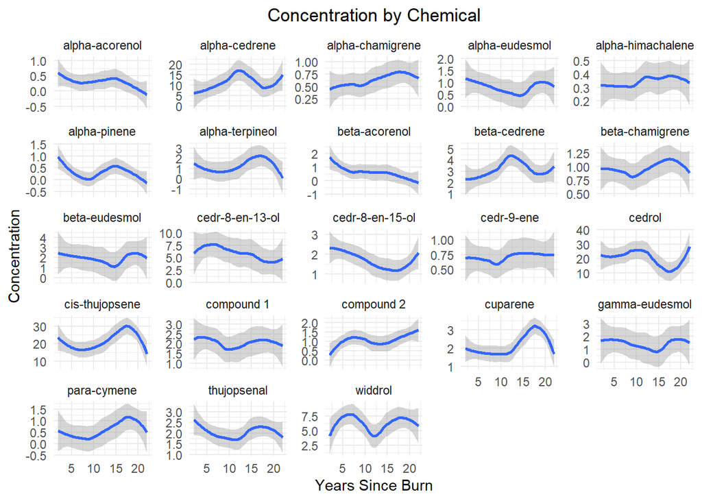

```r
Juniper_Oils %>%
  ggplot(aes(x=YearsSinceBurn, y=Concentration)) +
  facet_wrap(~ChemicalID, scales = "free_y") +
  geom_smooth(method = loess) +
  theme_minimal() +
  labs(x = "Years Since Burn",
       title = "Concentration by Chemical") +
  theme(plot.title = element_text(hjust = 0.5))
```

# Exporting the Plot:

ggsave saves the plot as an image file named “STUBBS_Fig_2.jpg” in the current working directory.

```r
# export to millerberg_Fig_2.jpg
ggsave("./STUBBS_Fig_2.jpg")
```

## Task 5: Generalized Linear Model

The final task is to use a (GLM) and tidy() function.

# Generalized Linear Model

```r
model2 <- glm(data = Juniper_Oils, formula = Concentration ~ ChemicalID * YearsSinceBurn)

model2_sum <- summary(Juniper_Oils)
```

# Tidy Data Frame:

Tidy function from the broom package is used to tidy up the model results.

```r
tidy <- tidy(model2)
```

# Subset Tidy Data Frame:

This give p-value and prints it for viewing.

```r
ttss <- tidy[c(tidy$p.value <= 0.05), ]
print(ttss)
```

```
## # A tibble: 6 × 5
##   term                                    estimate std.error statistic  p.value
##   <chr>                                      <dbl>     <dbl>     <dbl>    <dbl>
## 1 ChemicalIDalpha-cedrene                    7.88      1.93       4.08 4.97e- 5
## 2 ChemicalIDcedr-8-en-13-ol                  7.62      1.93       3.95 8.72e- 5
## 3 ChemicalIDcedrol                          22.5       1.93      11.7  5.12e-29
## 4 ChemicalIDcis-thujopsene                  17.3       1.93       8.95 2.93e-18
## 5 ChemicalIDwiddrol                          5.82      1.93       3.01 2.69e- 3
## 6 ChemicalIDcis-thujopsene:YearsSinceBurn    0.332     0.141      2.35 1.90e- 2
```